# VIS 2128 Assigment 3

Spatial Relationships

Mike Deloge, Katia Krotova, Raveena John

9/22/2021

Load packages.

```r
library(sf)
library(tidyverse)
library(ggthemes)
library(ggspatial)
library(units)
library(nngeo)
```

Load data.

```r
EV <- st_read("https://bostonopendata-boston.opendata.arcgis.com/datasets/465e00f9632145a1ad645a27d27069b4_2.kml?outSR=%7B%22latestWkid%22%3A2249%2C%22wkid%22%3A102686%7D",
                  quiet = TRUE)

centers <- st_read("https://bostonopendata-boston.opendata.arcgis.com/datasets/acedd06b39854088b0f2fefccffebf84_0.kml?outSR=%7B%22latestWkid%22%3A3857%2C%22wkid%22%3A102100%7D",
                   quiet = TRUE)

main <- st_read("https://bostonopendata-boston.opendata.arcgis.com/datasets/440c7ec0178d4c8593aecef7ea96bb4d_0.kml?outSR=%7B%22latestWkid%22%3A2249%2C%22wkid%22%3A102686%7D",
                 quiet = TRUE)

nhoods <- st_read("https://bostonopendata-boston.opendata.arcgis.com/datasets/3525b0ee6e6b427f9aab5d0a1d0a1a28_0.kml?outSR=%7B%22latestWkid%22%3A2249%2C%22wkid%22%3A102686%7D",
                 quiet = TRUE)
```

Transform data to be consistent with Massachusetts State Plane.

```r
MA_state_plane <- "+proj=lcc +lat_1=41.71666666666667 +lat_2=42.68333333333333 +lat_0=41 +lon_0=-71.5 +x_0=200000 +y_0=750000 +ellps=GRS80 +units=m +no_defs"

EV <- EV %>%
  st_transform(MA_state_plane)

centers <- centers %>%
  st_transform(MA_state_plane)

main <- main %>%
  st_transform(MA_state_plane)

nhoods <- nhoods %>%
  st_transform(MA_state_plane)
```

## Plots

### 1. Number and Proportion of Community Centers in Neighborhoods

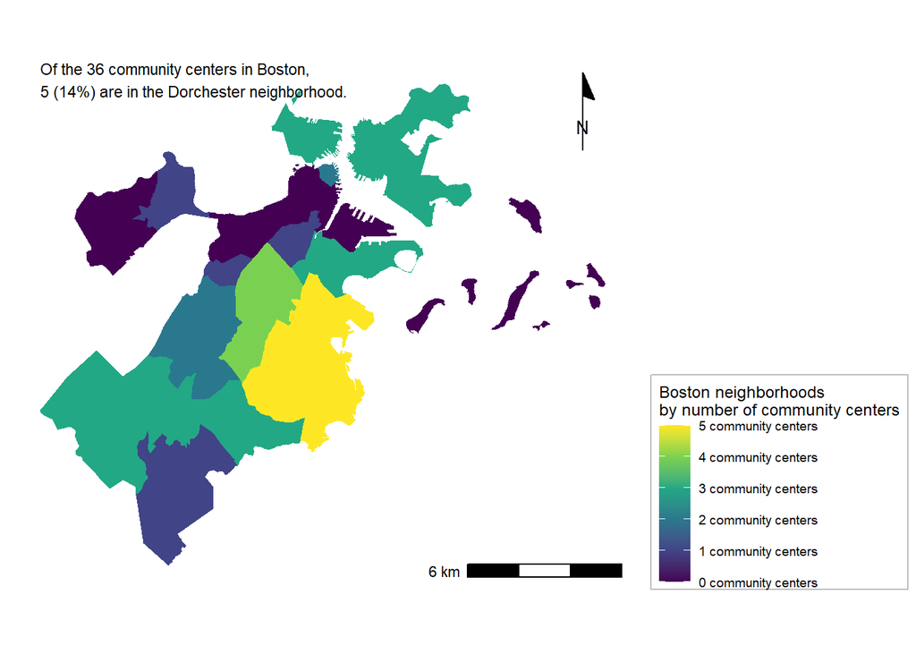

```r
nhoods <- nhoods %>%
  mutate(num_centers = lengths(st_covers(nhoods,centers)))

n_centers <- sum(nhoods$num_centers)
max_n_centers <- max(nhoods$num_centers)
pct_n_centers <- max_n_centers/n_centers
name_max_centers <- nhoods[ which(nhoods$num_centers=='5'),1]

left_side  <- st_bbox(nhoods)$xmin
top_side <- st_bbox(main)$ymax

ggplot(nhoods) +
  geom_sf(color = NA,
          aes(fill = num_centers)) +
  scale_fill_viridis_c(name = "Boston neighborhoods\nby number of community centers",
                       breaks = breaks <- seq(0, 5, by = 1),
                       labels = paste(prettyNum(breaks, big.mark = ","),
                                      "community centers")) +
  annotation_scale(location = "br") +
  annotation_north_arrow(location = "tr",
                         style = north_arrow_minimal()) +
  annotate(geom = "text", x = left_side,
           y = top_side+1800,
           label = paste("Of the ",
                         prettyNum(n_centers, big.mark = ","),
                         " community centers in Boston,\n",
                         prettyNum(max_n_centers, big.mark = ","),
                         " (",
                         prettyNum(100*pct_n_centers, digits = 0),
                         "%) are in the ",
                         name_max_centers$Name,
                         " neighborhood.",
                         sep = ""),
           hjust = 0, vjust = 0, size = 3) +
theme_map() +
  theme(legend.position = "right",
        legend.background = element_rect(fill = alpha("white", 0.5),
                                         color = "gray"))
```

This map shows the number of community centers, provided by the City of Boston and most recently updated in 2018, within each neighborhood. This map shows there are between 0 and 5 centers in each neighborhood and that the greatest number of community centers are located in the Dorchester neighborhood. It would be useful to look at the population of each neighborhood to consider the per capita distribution of community centers. Another aspect to consider is the specific locations of community centers, as a center near the border of a neighborhood could serve residents of multiple neighborhoods.

### 2. Number and Proportion of Neighborhoods that Overlap with Main Street Districts

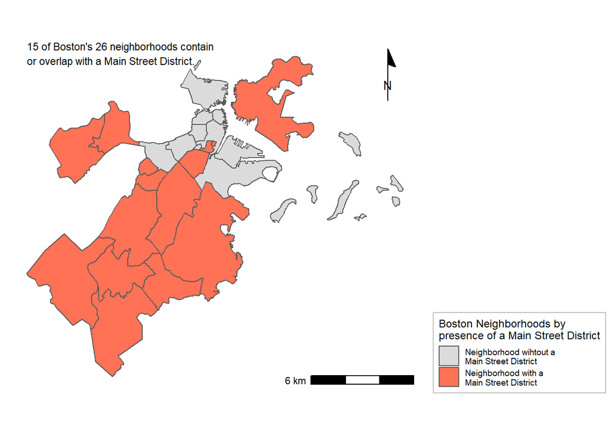

```r
nhoods <- nhoods %>%
  mutate(num_main = lengths(st_intersects(nhoods, main))) %>%
  mutate(has_main = num_main > 0)

n_nhoods_main <- sum(nhoods$has_main)

ggplot()+
  geom_sf(data = nhoods,
          aes(fill = has_main))+
    scale_fill_manual(values = c("gray86","coral1"),
              name = "Boston Neighborhoods by \npresence of a Main Street District",
              labels = c("Neighborhood wihtout a\nMain Street District", "Neighborhood with a\nMain Street District"))+
  annotation_scale(location = "br") +
  annotation_north_arrow(location = "tr",
                         style = north_arrow_minimal()) + annotate(geom = "text", x = left_side,
           y = top_side+1800,
           label = paste(n_nhoods_main ,
                         "of Boston's",
                         length(nhoods$Name),
                         "neighborhoods contain\nor overlap with a Main Street District."),
           hjust = 0, vjust = 0, size = 3) +
theme_map() +
  theme(legend.position = "right",
        legend.background = element_rect(fill = alpha("white", 0.5),
                                         color = "gray"))
```

This map shows the Boston neighborhoods that contain a designated Main Street District. These are commercial district organizations that promote and attract commerce to the area. The map clearly shows a lack of districts in the downtown area, but does not indicate the amount to which each neighborhood contains a district. This map would be a good starting point to examine the effectiveness of or need for Main Street Districts in the highlighted neighborhoods, which are geographically larger and likely less dense.

### 3. Number of Community Centers in Each Neighborhood

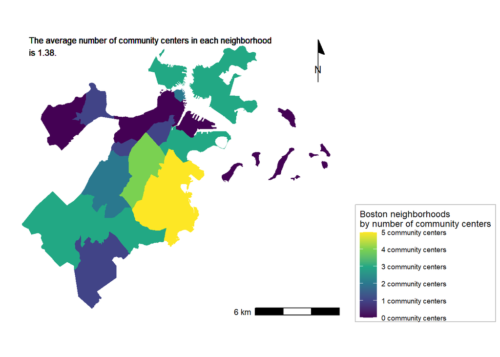

```r
nhoods <- nhoods %>%
  mutate(num_centers = lengths(st_covers(nhoods,centers)))

n_centers <- sum(nhoods$num_centers)
max_n_centers <- max(nhoods$num_centers)
pct_n_centers <- max_n_centers/n_centers
name_max_centers <- nhoods[ which(nhoods$num_centers=='5'),1]
ave_n_centers <- ave(nhoods$num_centers)


left_side  <- st_bbox(nhoods)$xmin
top_side <- st_bbox(main)$ymax

ggplot(nhoods) +
  geom_sf(color = NA,
          aes(fill = num_centers)) +
  scale_fill_viridis_c(name = "Boston neighborhoods\nby number of community centers",
                       breaks = breaks <- seq(0, 5, by = 1),
                       labels = paste(prettyNum(breaks, big.mark = ","),
                                      "community centers")) +
  annotation_scale(location = "br") +
  annotation_north_arrow(location = "tr",
                         style = north_arrow_minimal()) +
   annotate(geom = "text", x = left_side + 500,
           y = top_side + 1600,
             label = paste("The average number of community centers in each neighborhood\nis ",
                         prettyNum(ave_n_centers, digits = 3),
                         ".",
                         sep = ""),
           hjust = 0, vjust = 0, size = 3) +
theme_map() +
  theme(legend.position = "right",
        legend.background = element_rect(fill = alpha("white", 0.5),
                                         color = "gray"))
```

This map shows the average number of community centres in each neighborhood in Boston.

### 4. Average Distance between EV Stations and Main Street Districts

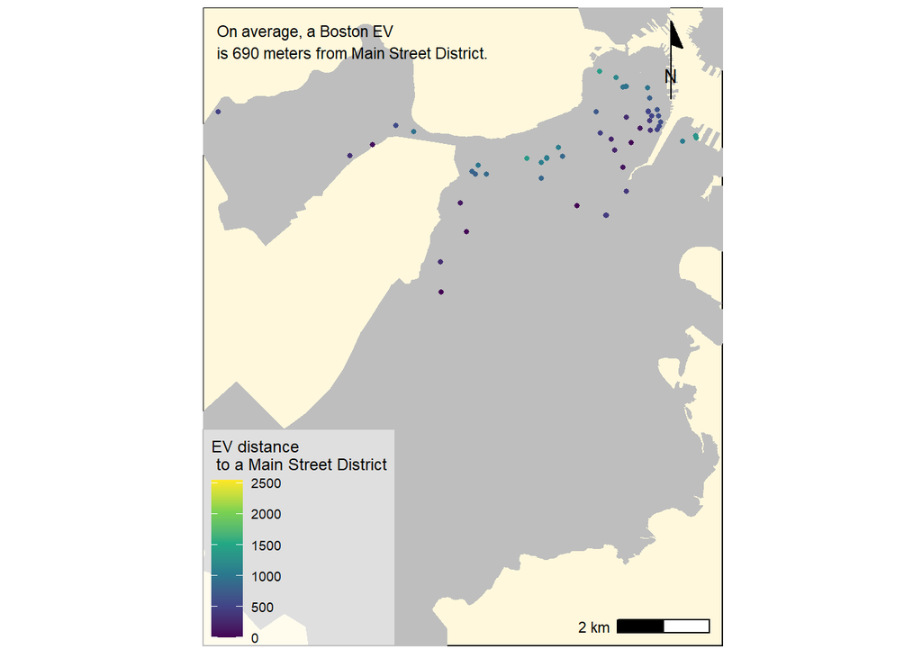

```r
EV <- EV %>%
  mutate(main_dist = st_nn(EV, main,
                           returnDist = TRUE)$dist) %>%
  mutate(main_dist = as.numeric(main_dist))

avg_main_dist <- mean(EV$main_dist)


right_side <- st_bbox(main)$xmax
left_side  <- st_bbox(main)$xmin
top_side <- st_bbox(main)$ymax
bottom_side <- st_bbox(main)$ymin


  ggplot(nhoods) +
  geom_sf(fill = "gray", color = NA) +
  geom_sf(data = EV, size = 1,
          aes(color = main_dist)) +
  coord_sf(xlim = c(left_side, right_side),
           ylim = c(bottom_side, top_side), expand = FALSE) +
  scale_color_viridis_c(name =
                          "EV distance\n to a Main Street District") +
  annotation_scale(location = "br") +
  annotation_north_arrow(location = "tr",
                         style = north_arrow_minimal()) +
  annotate(geom = "text", x = left_side + 300,
           y = top_side - 1100,
           label = paste("On average, a Boston EV\nis ",
                         prettyNum(avg_main_dist, digits = 3),
                         " meters from Main Street District.",
                         sep = ""),
           hjust = 0, vjust = 0, size = 3) +
  theme_map() +
  theme(panel.background = element_rect(fill = "cornsilk1"),
        legend.background = element_rect(fill = alpha("white", 0.5),
                                         color = "gray"))
```

This map shows an average distance between an Electric Vehicle station and Main Street District in Boston.

### 5. Number and Proportion of EV Charging Stations within 500m of a Community Center

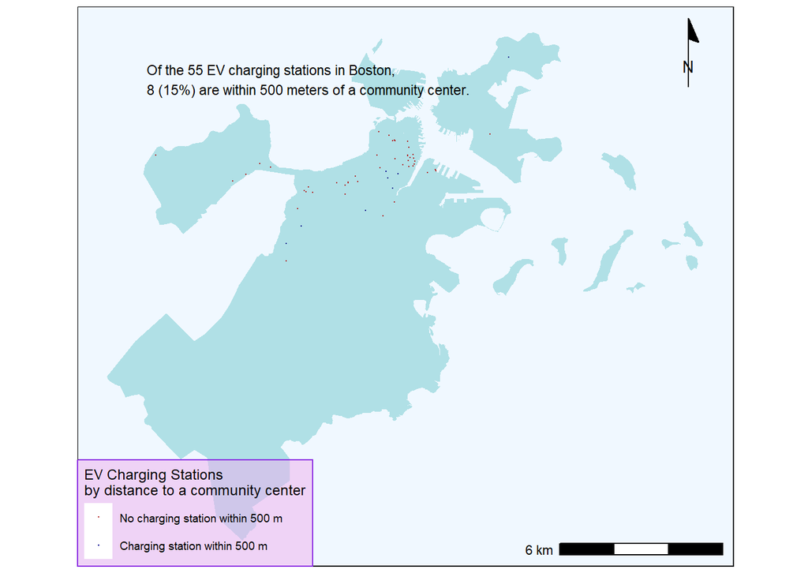

```r
centers_buffer <- st_buffer(centers, dist = 500) %>%
  st_union()

EV_centers <- EV[centers_buffer,]

EV <- EV %>%
  st_join(EV_centers) %>%
  mutate(by_centers = !is.na(Name.y))

n_EV_centers <- sum(EV$by_centers)


n_EV <- length(EV$by_centers)

pct_EV_centers <- n_EV_centers / n_EV



ggplot() +
   geom_sf(data = nhoods, fill = "powderblue", color = NA) +

  geom_sf(data = EV, size = 0.025,
          aes(color = by_centers)) +
  scale_color_manual(values = c("firebrick", "blue4"),
          name = "EV Charging Stations\nby distance to a community center",
          labels = c("No charging station within 500 m",
                     "Charging station within 500 m")) +
  annotation_scale(location = "br") +
  annotation_north_arrow(location = "tr",
                         style = north_arrow_minimal()) +
  annotate(geom = "text", x = left_side,
           y = top_side,
           label = paste("Of the ",
                         prettyNum(n_EV, big.mark = ","),
                         " EV charging stations in Boston,\n",
                         prettyNum(n_EV_centers, big.mark = ","),
                         " (",
                         prettyNum(100*pct_EV_centers, digits = 0),
                         "%) are within 500 meters of a community center.",
                         sep = ""),
           hjust = 0, vjust = 0, size = 3) +
  theme_map() +
  theme(panel.background = element_rect(fill = "aliceblue"),
        legend.background = element_rect(fill = alpha("plum2", 0.5),
                                         color = "blueviolet"))
```

### 6. Boston Neighborhoods by Number of EV Charging Stations

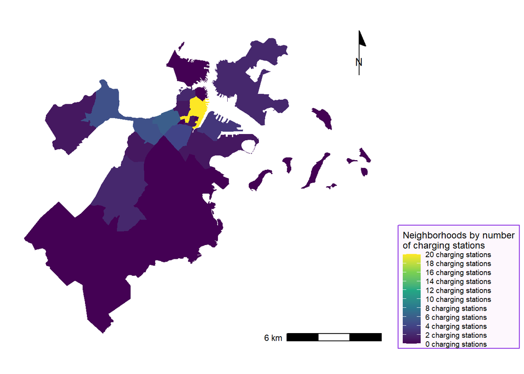

```r
left_side  <- st_bbox(main)$xmin
top_side <- st_bbox(main)$ymax

nhoods <- nhoods %>%
  mutate(num_EV = lengths(st_covers(nhoods, EV)))

ggplot(nhoods) +
  geom_sf(color = NA,
          aes(fill = num_EV)) +
  scale_fill_viridis_c(name = "Neighborhoods by number\nof charging stations",
                       breaks = breaks <- seq(0, 20, by = 2),
                       labels = paste(prettyNum(breaks, big.mark = ","),
                                      "charging stations")) +
  annotation_scale(location = "br") +
  annotation_north_arrow(location = "tr",
                         style = north_arrow_minimal()) +

theme_map() +
  theme(legend.position = "right", legend.background = element_rect(fill = alpha("plum2", 0.1),
                                         color = "blueviolet"))
```

This map shows the prevalence of EV charging stations broken down by neighborhood. As seen by the yellow coloring, one of Boston’s neighborhoods has a proportionately high concentration of EV charging stations while many portions of the city have very few charging stations, if any at all. Several neighborhoods are in the middle range, each containing somewhere in the range of 4-10 EV charging stations.

### Team distribution of points

When working on this assignment, we worked collectively as a team by going through tutorials, discussing data sets and troubleshooting problems. Each member of the team made two individual maps, and therefore contributed equally to the finished product. We therefore recommend distributing 10 points equally to each member of our team.